# R Notebook

```r
library(tidyverse)
source("../../day_1/prob.R")
```

```r
tosscoin(1) %>%
  mutate(p = 1/ n())
```

| toss1 | p |
| --- | --- |
| H | 0.5 |
| T | 0.5 |

```r
NA
```

```r
s_three_coins <- tosscoin(3)
```

Task - 2 mins what is the probability of each of the eight outcomes if all of the coins are unbiased? What does ‘unbiased’ mean here? Why is it important that each of the coins are unbiased in this calculation?

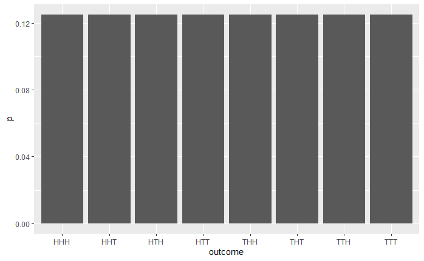

```r
s_three_coins_labelled <- s_three_coins %>%
  mutate(outcome = str_c(toss1, toss2, toss3, sep = ""),
         p = 1 / n())


s_three_coins_labelled %>%
  ggplot(aes(x = outcome, y = p)) +
  geom_col() # uniform distribution
```

We have assumed above that each coin is equally likely to land as heads or tails. This is a uniform distribution.

What are the probabilities of getting 0 heads, 1 head, 2 heads or 3 heads when tossing 3 coins?

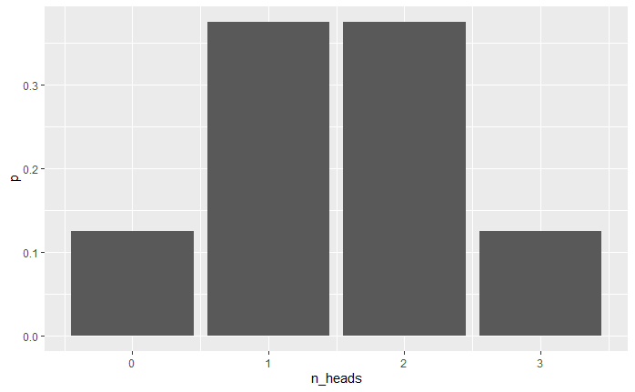

```r
s_three_coins_labelled %>%
  mutate(n_heads = str_count(outcome, "H")) %>%
  group_by(n_heads) %>%
  summarise(p = sum(p)) %>%
  ggplot(aes(x = n_heads, y = p)) +
  geom_col()
```

The probability distribution is no longer uniform. We would call this a *discrete* probability distribution. (finite/countable)

```r
library(janitor)
library(lubridate)
```

[output not shown]

[output cut: 27 more lines]

```r
sales_freqs <- air_con_clean %>%
  tabyl(units_sold)

sales_freqs
```

```
 units_sold n    percent
          0 3 0.08108108
          1 2 0.05405405
          2 2 0.05405405
          3 9 0.24324324
          4 8 0.21621622
          6 3 0.08108108
          8 1 0.02702703
          9 1 0.02702703
         10 2 0.05405405
         11 3 0.08108108
         12 2 0.05405405
         43 1 0.02702703
```

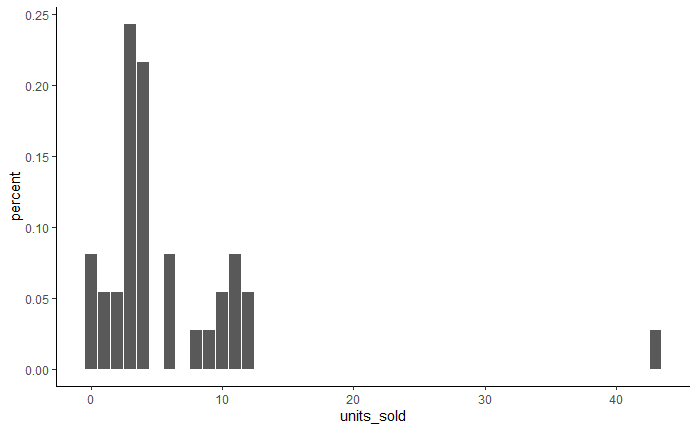

```r
sales_freqs %>%
  ggplot(aes(x = units_sold,
             y = percent)) +
  geom_col() +
  theme_classic()
```

```r
air_con_sales %>%
  summarise(mean_daily_sales = mean(Units_sold),
            median_daily_sales = median(Units_sold),
            mode_daily_sales = get_mode(Units_sold))
```

| mean_daily_sales | median_daily_sales | mode_daily_sales |
| --- | --- | --- |
| 5.945946 | 4 | 3 |

```r
NA
```

```r
get_mode <- function(data){

  tabled_data <- table(data)
  table_names <- names(tabled_data)

  return( as.numeric(table_names[tabled_data == max(tabled_data)]) )

}
```

mean = 6 median = 4 mode = 3

# Quantifying skew

```r
library(e1071)
```

When quantifying skew we can use the following class table

magnitude classification <0.5 fairly symmetric 0.5 - 1 moderately skewed >1 highly skewed

direction classification negative left skew positive right skew

skew = -0.8 (moderately left-skewed) skew = 1.2 (highly right-skewed)

[output not shown]

# Measures of Spread

```r
jobs <- read_csv("data/TyrellCorpJobs.csv") %>%
  clean_names() %>%
  select(-1)
jobs
```

| position | salary |
| --- | --- |
| Accounting | 34397 |
| Accounting | 30359 |
| Management | 50036 |
| Accounting | 34716 |
| Accounting | 35786 |
| Accounting | 34395 |
| Accounting | 35867 |
| Accounting | 35388 |
| Management | 57823 |
| Accounting | 32532 |

[output cut: 165 more lines]

```r
jobs %>%
  summarise(range = diff(range(salary)))
```

| range |
| --- |
| 61568 |

```r
NA
```

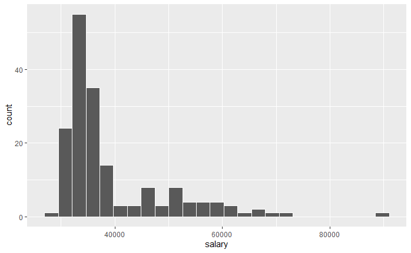

```r
jobs %>%
  ggplot(aes(x = salary)) +
  geom_histogram(col = "white", bins = 25)
```

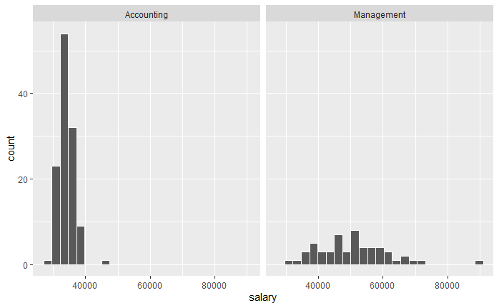

```r
jobs %>%
  ggplot(aes(x = salary)) +
  geom_histogram(col = "white", bins = 25) +
  facet_wrap(~position)
```

There is strong evidence of bimodality. From now on, consider the two distributions (one for each position).

```r
jobs %>%
  group_by(position) %>%
  summarise(range = diff(range(salary)))
```

| position | range |
| --- | --- |
| Accounting | 15535 |
| Management | 59366 |

```r
NA
```

There is more salary disparity in Management than in Accounting.

Range is heavily affected by extreme values.

# Interquartile range

```r
jobs %>%
  group_by(position) %>%
  summarise(q1 = quantile(salary, 0.25),
            q2_median = quantile(salary, 0.5),
            q3 = quantile(salary, 0.75),
            iqr = q3 - q1,
            iqr_function = IQR(salary))
```

| position | q1 | q2_median | q3 | iqr | iqr_function |
| --- | --- | --- | --- | --- | --- |
| Accounting | 32390.5 | 34150 | 35265.0 | 2874.5 | 2874.5 |
| Management | 43698.0 | 50300 | 57288.5 | 13590.5 | 13590.5 |

```r
NA
```

The five figure summary:

salary  
Min. :29459 (lowest value) 1st Qu.:33039 (q1) Median :35009 (q2 = median) 3rd Qu.:41990 (q3) Max. :91027 (highest value)

```r
library(skimr)
jobs %>%
  group_by(position) %>%
  skim()
```

```
── Data Summary ────────────────────────
                           Values
Name                       Piped data
Number of rows             175
Number of columns          2
_______________________
Column type frequency:
  numeric                  1
________________________
Group variables            position
```

|  | skim_variable | position | n_missing | complete_rate | mean | sd | p0 | p25 | p50 | p75 | p100 | hist |
| --- | --- | --- | --- | --- | --- | --- | --- | --- | --- | --- | --- | --- |
| 1 | salary | Accounting | 0 | 1 | 34115.02 | 2383.676 | 29459 | 32390.5 | 34150 | 35265.0 | 44994 | ▅▇▃▁▁ |
| 2 | salary | Management | 0 | 1 | 50876.15 | 10940.555 | 31661 | 43698.0 | 50300 | 57288.5 | 91027 | ▅▇▅▁▁ |

# Box plots

Box and whisker hinge-plots tukey-plots (popularised by John Tukey)

Elements of a box plot

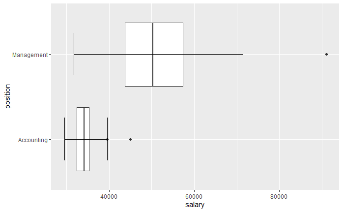

```r
jobs %>%
  ggplot() +
  aes(x = salary, y = position) +
  geom_boxplot() +
  stat_boxplot(geom = "errorbar", width = 0.5)
```

## Task - 10 mins

Investigate and comment on the centrality and spreads of distribution_1 and distribution_2 produced by the following function calls. Use geom_boxplot() and skim() first Next, plot histograms to confirm your descriptions. [Don’t worry about what the functions generating distribution_1 and distribution_2 are doing]

```r
set.seed(42)
distribution_1 <- tibble(
  y = append(rnorm(n = 100, mean = 5, sd = 10), rnorm(n = 200, mean = 5, sd = 1))
)

distribution_2 <- tibble(
  y = runif(n = 1000, min = -30, max = 30)
)
```

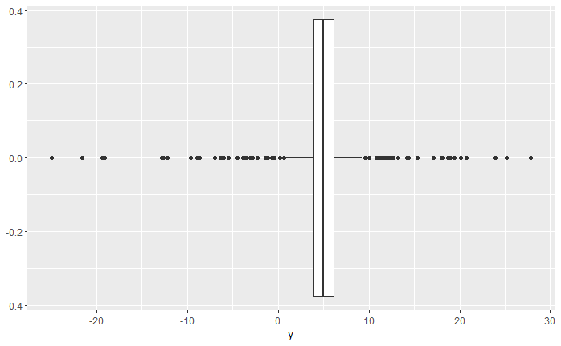

```r
distribution_1 %>%
  ggplot(aes(y)) +
  geom_boxplot()
```

```r
distribution_1 %>%
  skim()
```

```
── Data Summary ────────────────────────
                           Values
Name                       Piped data
Number of rows             300
Number of columns          1
_______________________
Column type frequency:
  numeric                  1
________________________
Group variables            None
```

|  | skim_variable | n_missing | complete_rate | mean | sd | p0 | p25 | p50 | p75 | p100 | hist |
| --- | --- | --- | --- | --- | --- | --- | --- | --- | --- | --- | --- |
| 1 | y | 0 | 1 | 5.075765 | 6.045745 | -24.9309 | 3.945366 | 4.976071 | 6.115762 | 27.86645 | ▁▁▇▂▁ |

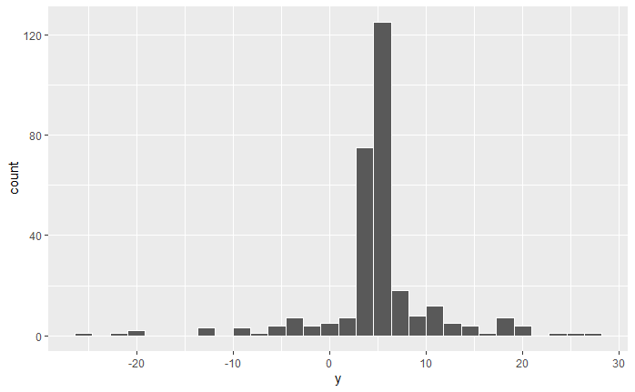

```r
distribution_1 %>%
  ggplot(aes(y)) +
  geom_histogram(col = "white")
```

```r
NA
NA
```

Distribution 1 has concentrated values around 5 with a large spread in the data (i.e. lots of values considered outliers)

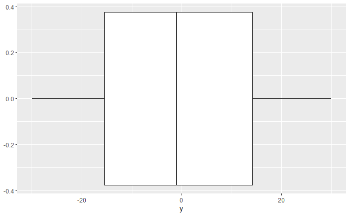

```r
distribution_2 %>%
  ggplot(aes(y)) +
  geom_boxplot()
```

```r
distribution_2 %>%
  skim()
```

```
── Data Summary ────────────────────────
                           Values
Name                       Piped data
Number of rows             1000
Number of columns          1
_______________________
Column type frequency:
  numeric                  1
________________________
Group variables            None
```

|  | skim_variable | n_missing | complete_rate | mean | sd | p0 | p25 | p50 | p75 | p100 | hist |
| --- | --- | --- | --- | --- | --- | --- | --- | --- | --- | --- | --- |
| 1 | y | 0 | 1 | -0.7187298 | 17.32224 | -29.92365 | -15.48538 | -0.9870809 | 14.17994 | 29.96274 | ▇▇▇▇▇ |

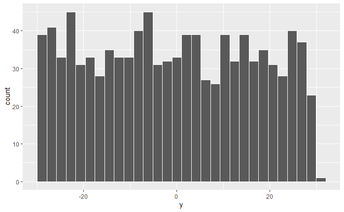

```r
distribution_2 %>%
  ggplot(aes(y)) +
  geom_histogram(col = "white")
```

This distribution tends to follow a uniform distribution with a large spread of data (and interquartile ranges). Each quartile range is approximately the same size.

## Variance

Single number value for the measure of spread

a measure of how far each value in the dataset is from the mean.

Sum of the difference from the mean squared and then divided by the number of elements - 1

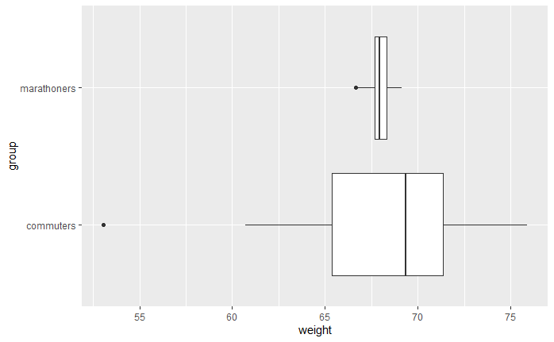

```r
set.seed(42)

londoner_weights <- tibble(
  marathoners = rnorm(50, mean = 68, sd = 0.5),
  commuters = rnorm(50, mean = 68, sd = 5)
) %>%
  pivot_longer(cols = everything(), names_to = "group", values_to = "weight")

ggplot(londoner_weights) +
  aes(x = weight, y = group) +
  geom_boxplot()
```

```r
londoner_weights %>%
  group_by(group) %>%
  summarise(mean_weight = mean(weight),
            var_weight = var(weight),
            st_dev_weight = sd(weight),
            st_dev_weight_long = sqrt(var_weight))
```

| group | mean_weight | var_weight | st_dev_weight | st_dev_weight_long |
| --- | --- | --- | --- | --- |
| commuters | 68.50351 | 21.3898332 | 4.6249144 | 4.6249144 |
| marathoners | 67.98216 | 0.3314745 | 0.5757382 | 0.5757382 |

```r
NA
```

weight = kg variance = kg^2

standard deviation (sd) = sqrt(variance) units = kg

The average deviance from the mean weight of commuters (68.5kg) was 4.6kg

Calculating variance longhand

$$s^2 = \frac{1}{n-1}\sum{(x - \bar{x})^2}$$

Get the difference between each value and the mean, square each value, add up these squared values and divide by total number of values - 1

…or

just use var()

sqrt the value you get for variance to calculate standard deviation

### Task:

Calculate the standard deviation for the salaries in accounting and management at Tyrell Corp.

Comment on the standard deviations.

```r
jobs %>%
  group_by(position) %>%
  summarise(mean_salary = mean(salary),
            var_salary = var(salary),
            sd_salary = sd(salary),
            sd_percent = sd_salary / mean_salary)
```

| position | mean_salary | var_salary | sd_salary | sd_percent |
| --- | --- | --- | --- | --- |
| Accounting | 34115.02 | 5681909 | 2383.676 | 0.06987174 |
| Management | 50876.15 | 119695746 | 10940.555 | 0.21504292 |

```r
NA
```

The sd for accounting is small (only $2,400) which indicates the salary values are all pretty similar, i.e. grouped closely around the mean.

Whereas for Management, the sd is a lot larger ($10,900) which states there is bigger variance between the salaries and that the salaries tend to be a bit further away from the mean.

# Common Distributions

Discrete and Continuous Variables

Numeric data - discrete / continuous Categorical data - nominal / ordinal (have an order)

discrete = countable and finite continuous = uncountable

Variables

number of people in my survey who love the colour blue = discrete value the height of people in Scotland - continuous value

age ==== continous numeric age group (child, adult, senior) === ordinal categoric number of people in household === discrete numeric height === continuous weight === continuous shoe size (uk) === ordinal categoric foot size === continuous numeric vegetarian === nominal categoric (binary)

# Probability Mass and Probability Density Functions

Discrete probability distribution is a probability distribution of a discrete variable

heads or tails, discrete number of outcomes

probability mass function -> probability distribution of a discrete variable

probability density function -> probability distribution of a continuous variable

(What is the probability of heights in the range from 174.22cm to 178.91cm in the dataset?)

In the case of pmf vs pdf, while we can measure probabilities for specific discrete values of a pmf, we can’t for pdf. We look instead at the probability of a range of values.

Rules for probability distributions - outcome is our x axis - y is our probability of that outcome occurring (pmfs) - the sum of all probabilities must be 1 - each probability must be between 0 and 1.

Rules for continuous probability distributions - outcomes are still our x axis - y is probability function - the area under the pdf curve must be equal to 1 - probabilities are the area under the curve bounded by an upper and lower value

# Discrete Distributions

Discrete uniform - all outcomes equally likely (same probability)

# Cumulative Distribution Functions

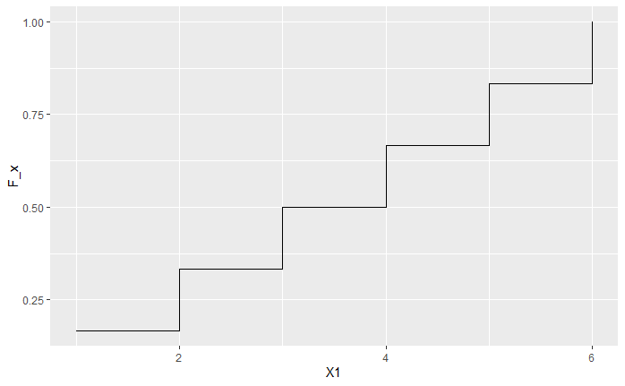

```r
#cdf for rolling one die
rolldie(1) %>%
  mutate(p = 1/n()) %>%
  mutate(F_x = cumsum(p)) %>%
  ggplot(aes(x = X1, y = F_x)) +
  geom_step()
```

```r
NA
NA
NA
```

Getting individual probabilities from cdfs

p(3) = F(3) - F(2) = 0.5 - 0.3333 = 0.16666….

p(4) = F(4) - F(3) = 0.6667 - 0.5 = 0.16666….

# Continuous Distributions

continuous Uniform

Lengths of “brain break” at CodeClan were monitored for a week. They were found to be distributed uniformly (equal p for all outcomes) between 5 mins and 22 mins.

l is continuous l could be 7.182333, it could 5 mins, it could be 21.9 mins

What will the probability density function look like for the random variable l?

Useful distribution functions

p - cumulative density function q - quantile r - random numbers d - distribution

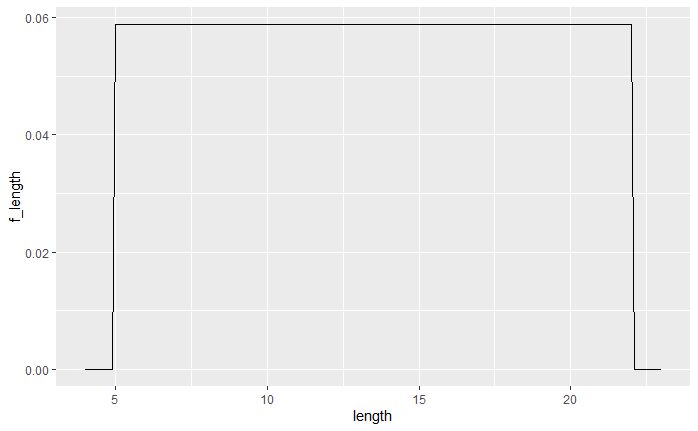

```r
brain_breaks <- tibble(
  length = seq(4, 23, 0.1),
  f_length = dunif(x = length, min = 5, max = 22)
)

# probability density function (we're looking at a continuous var)
brain_breaks %>%
  ggplot(aes(x = length, y = f_length)) +
  geom_line()
```

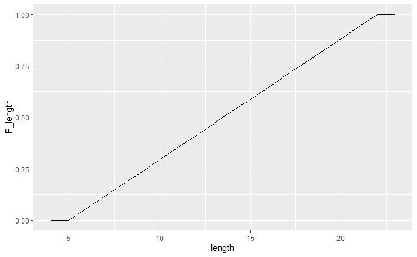

```r
brain_breaks %>%
  mutate(F_length = punif(q = length, min = 5, max = 22)) %>%
  ggplot(aes(x = length, y = F_length)) +
  geom_line()
```

```r
NA
NA
```

What is the probability of a brain break lasting between 8.4 and 10.7 mins?

```r
f_10_7 <- punif(q = 10.7, min = 5, max = 22)
f_8_4 <- punif(q = 8.4, min = 5, max = 22)

f_10_7 - f_8_4
```

```
[1] 0.1352941
```

14% chance of seeing a brain break between 8.4 and 10.7 mins long.

What does this look like on our initial plot

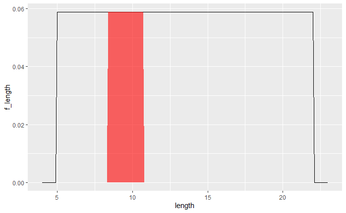

```r
brain_breaks %>%
  ggplot(aes(x = length, y = f_length)) +
  geom_line() +
  #add shading
  geom_ribbon(aes(ymin = 0, ymax = ifelse(
    length >= 8.4 & length <= 10.7, f_length, 0)),
    fill = "red", alpha = 0.6
  )
```

```r
NA
NA
```

```r
(10.7 - 8.4) * max(brain_breaks$f_length)
```

```
[1] 0.1352941
```

# Normal Distribution

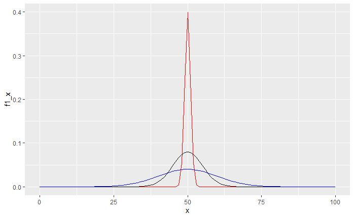

```r
three_norms <- tibble(
  x = seq(0, 100, 1),
  f1_x = dnorm(x = x, mean = 50, sd = 1),
  f2_x = dnorm(x = x, mean = 50, sd = 5),
  f3_x = dnorm(x = x, mean = 50, sd = 10),
)

three_norms %>%
  ggplot() +
  geom_line(aes(x = x, f1_x), col = "red") +
    geom_line(aes(x = x, f2_x), col = "black") +
    geom_line(aes(x = x, f3_x), col = "blue")
```

```r
NA
NA
```

How can we tell if our data is normally distributed?

qqplot (quantile quantile plots) various normality tests

look at a normal distribution vs our data

(fitting a normal distribution to our data set)

Looking at just the accounting department, is the data normally distributed?

```r
accounting_position_stats <- jobs %>%
  filter(position == "Accounting") %>%
  summarise(num = n(),
            mean_sal = mean(salary),
            st_dev_sal = sd(salary))
accounting_position_stats
```

| num | mean_sal | st_dev_sal |
| --- | --- | --- |
| 120 | 34115.02 | 2383.676 |

```r
NA
```

Overlaying a normal distribution:

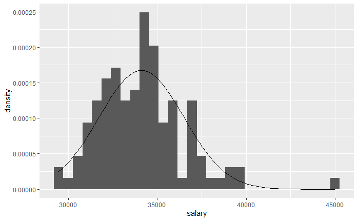

```r
# 1. plot the histogram
# 2. change the metric of the histogram with aes(y = ..density..)
#3. use stat_function and pre_calculated stats to overlay a normal distribution


jobs %>%
  filter(position == "Accounting") %>%
  ggplot(aes(salary)) +
  geom_histogram(aes(y = ..density..)) +
  stat_function(
    fun = ~dnorm(., mean = accounting_position_stats$mean_sal,
                sd = accounting_position_stats$st_dev_sal)
  )
```

“Standard Normal”

Standardised variable (tool to describe normal distributions)

z of a value = (value - mean) / s

Something that tells us how far away we are from the mean in units of standard deviation.

Z = 1.3, then the value is 1.3 sd away from the mean value. z = 3 would be a value 3* sd away from the mean

This is another definition of an outlier:

- a value 1.5*IQR above Q3 or below Q1
- any value with a z above or below 3

```r
management_scaled <- jobs %>%
  filter(position == "Management") %>%
  #scale automatically calculates z scores
  mutate(z_salary = scale(salary)) %>%
  mutate(mean_sal = mean(salary))

management_scaled
```

| position | salary | z_salary | mean_sal |
| --- | --- | --- | --- |
| Management | 50036 | -0.076791849 | 50876.15 |
| Management | 57823 | 0.634963626 | 50876.15 |
| Management | 60180 | 0.850400592 | 50876.15 |
| Management | 52290 | 0.129230604 | 50876.15 |
| Management | 44425 | -0.589654308 | 50876.15 |
| Management | 42971 | -0.722554329 | 50876.15 |
| Management | 67832 | 1.549816657 | 50876.15 |
| Management | 64078 | 1.206689644 | 50876.15 |
| Management | 33849 | -1.556332863 | 50876.15 |
| Management | 55649 | 0.436253417 | 50876.15 |

[output cut: 45 more lines]

```r
management_scaled %>%
  filter(abs(z_salary) > 2)
```

| position | salary | z_salary | mean_sal |
| --- | --- | --- | --- |
| Management | 91027 | 3.66991 | 50876.15 |

Standard Normal

scaled so that mean = 0, sd = 1

Shading the standard normal (in notes)

The empirical 3-sigma rule

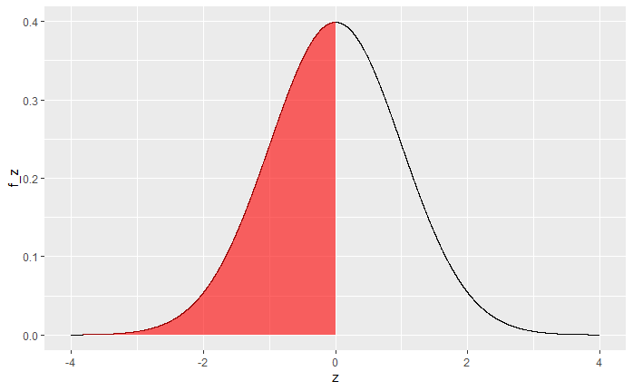

```r
shade_standard_normal <- function(shade_from, shade_to){
  standard_normal <- tibble(
    z = seq(from = -4, to = 4, by = 0.001),
    f_z = dnorm(x = z)
  )
  standard_normal %>%
    ggplot(aes(x = z, y = f_z)) +
    geom_line() +
    geom_ribbon(aes(ymin = 0, ymax = ifelse(z >= shade_from & z <= shade_to, f_z, 0)), fill = "red", alpha = 0.6)
}

shade_standard_normal(shade_from = -Inf, shade_to = 0)
```

Let’s calculate how many values should lie within 1 standard distribution of the mean for a standard normal distribution.

```r
# one standard deviation above - one standard deviation below
100 * (dnorm(q = 1) - dnorm(q = -1))
```

[output not shown]

```r
# two standard deviation above - two standard deviation below
100 * (pnorm(q = 2) - pnorm(q = -2))
```

```
[1] 95.44997
```

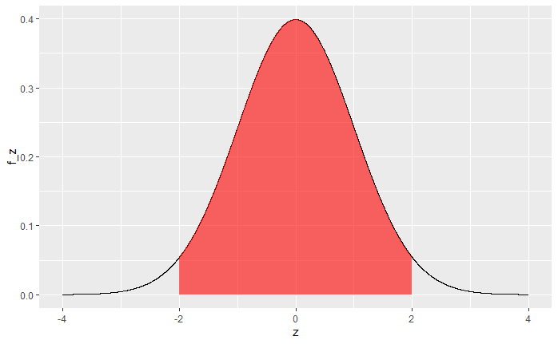

```r
shade_standard_normal(-2, 2)
```

This is called the empirical 3 sigma rule

For data that is normally distributed we expect: 68% values lie within 1 sd 95% values lie within 2 sd 99.7% values lie within 3 sd.